# Quantification des types cellulaires et classification des oligodendrocytes

L'objectif est de quantifier le nombre d'astrocytes et d'oligodendrcoytes pour chaque condition (GMCSF, IL4 et LPS) chez le contrôle et chez le patient. Une classification en quatres classes des cellules oligodendrocytaires pour chaque condition (GMCSF, IL4 et LPS) est réalisée chez le contrôle et chez le patient. Les quatres classes sont :

- Oligodendrocytes non différenciés avec moins de 150 branches
- Oligodendrocytes différenciés entre 150 et 300 branches
- Oligodendrocytes différenciés entre 300 et 450 branches
- Oligodendrocytes différenciés avec plus de 450 branches

Vous avez un répertoire contenant les images de l'ensemble des puits, ces images sont analysés par les macros de comptage et de classification via *imageJ FIJI* et produit des fichier au format CSV contenant des résultats quantitatif sur le comptage des types cellulaire et la classification des oligodendrocytes. L'analyse quantitatif des résultats est réalisée à l'aide d'un script python depuis *Jupyter Notebook*.

**Vérifier que vous disposez du répertoire contenant l'ensemble des puits (exemple : ARRAYSCAN_221129130001_PB), la macro de comptage et la macro de classification, vous avez le logiciel imageJ FIJI et l'environnement Anaconda. Si vous n'avez pas un des logiciel installer le avant de poursuivre la lecture de cette fiche utilisateur.** Installer **ImageJ FIJI** : https://imagej.net/software/fiji/downloads, installer **Anaconda** :https://www.anaconda.com/download.

## Installer les bibliothèques pandas et matplotlib

Lorsque les logiciels sont installés, ajouter les bibliothèques **pandas** qui permet la manipulation et analyse des données et **matplotlib** qui permet de tracer et visualiser des données sous forme de graphique à l'environnement *Anaconda*. Vous pouvez suivre les étapes détaillés de la fiche *installer_bibliothèque*. Lorsque les bibliothèques **pandas** et **matplotlib** sont installées vous pouvez lancer le script python depuis *Jupyter Notebook* et suivre les instruction présente dans les sections textes du script. Pour lancer le script veuillez suivre les instructions suivante:

## Lancer le script python

- Ouvrir "Jupyter Notebook"

[figure not shown]

- Ouvrir le script *Classification.ipynb, Suppime .DIB et regrouper les puits.ipynb ou Comptage.ipynb* et suivre les instructions présentes sur le script.

[figure not shown]

- Cliquer sur le bouton *Run* en bas du menu pour exécuter le script.

## Lancer la macro de comptage ou la macro de classification

Lancer une macro nécessite l'ouverture du logiciel *imageJ FIJI*, suivre les étapes suivante pour lancer une macro:

- Ouvrir le logiciel **imageJ FIJI**
- Ouvrir une fenêtre pour la macro **Plugin > New > Macro**
- Ouvrir la macro que vous souhaitez lancer, soit la *macro de comptage* soit la *macro de classification* **File > Open** et choisir la macro.

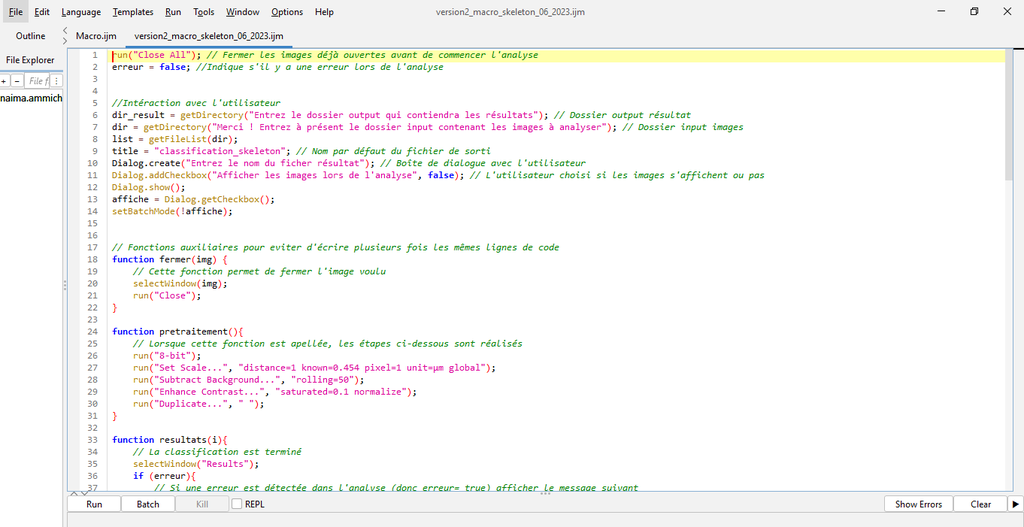

- Lancer la macro avec le bouton **Run** en bas à gauche et suivre les instructions présente dans les fenêtres qui vont s'ouvrir.

## Modifier le script python

Si vous souhaitez comprendre comment fonction le code et vous souhaitez le modifier vous pouvez lire la fiche **Modifier le script python** qui contient une section *étapes par étpaes* pour comprendre les lignes de code principales et une section *Modification du script classification* qui montre un exemple avec le nombre de jonctions.